# SupremeCourt

stevens 의 판결을 여러 가지 변수를 써서 예측한다.

데이터 구조는 다음과 같다.

```r
str(cases)
```

```
## 'data.frame':    566 obs. of  7 variables:
##  $ Circuit   : Factor w/ 13 levels "10th","11th",..: 4 11 7 3 9 11 13 11 12 2 ...
##  $ Issue     : Factor w/ 11 levels "Attorneys","CivilRights",..: 5 5 5 5 9 5 5 5 5 3 ...
##  $ Petitioner: Factor w/ 12 levels "AMERICAN.INDIAN",..: 2 2 2 2 2 2 2 2 2 2 ...
##  $ Respondent: Factor w/ 12 levels "AMERICAN.INDIAN",..: 2 2 2 2 2 2 2 2 2 2 ...
##  $ LowerCourt: Factor w/ 2 levels "conser","liberal": 2 2 2 1 1 1 1 1 1 1 ...
##  $ Unconst   : int  0 0 0 0 0 1 0 1 0 0 ...
##  $ Reverse   : int  1 1 1 1 1 0 1 1 1 1 ...
```

모델을 만들기에 앞서 최저 기준점을 만들어야 한다. **baseline 은 0.55**이다. 정확도는 이 수치보다는 높아야 한다.

```r
table(cases$Reverse)
```

```
##
##   0   1
## 257 309
```

```r
baseline = 309/nrow(cases)
```

[output not shown]

모델을 만들기에 앞서 데이터를 train, test 로 나눈다.

```r
library(caTools)
set.seed(822)
split = sample.split(cases$Reverse, SplitRatio = 0.7)
train = subset(cases, split == TRUE)
test = subset(cases, split == FALSE)
```

### Logistic Model

#### Model 만들기

```r
logMod = glm(Reverse ~ ., data=train, family=binomial)
summary(logMod)
```

```
##
## Call:
## glm(formula = Reverse ~ ., family = binomial, data = train)
##
## Deviance Residuals:
##     Min       1Q   Median       3Q      Max
## -2.1354  -0.8793   0.3237   0.8739   2.0209
##
## Coefficients:
##                                        Estimate Std. Error z value
## (Intercept)                            14.63376  882.74550   0.017
## Circuit11th                             0.57171    0.62466   0.915
## Circuit1st                              0.70652    0.82112   0.860
## Circuit2nd                              1.19705    0.65718   1.821
## Circuit3rd                              0.02745    0.75879   0.036
## Circuit4th                              1.23519    0.70275   1.758
## Circuit5th                              1.54747    0.66316   2.333
## Circuit6th                              0.97153    0.74799   1.299
## Circuit7th                              0.14640    0.62713   0.233
## Circuit8th                             -0.33910    0.64369  -0.527
## Circuit9th                              0.75688    0.55996   1.352
## CircuitDC                               0.18093    0.74793   0.242
## CircuitFED                             -0.23004    0.78257  -0.294
## IssueCivilRights                      -13.22313  882.74370  -0.015
## IssueCriminalProcedure                -13.71329  882.74372  -0.016
## IssueDueProcess                       -13.58611  882.74380  -0.015
## IssueEconomicActivity                 -12.87528  882.74365  -0.015
## IssueFederalismAndInterstateRelations -13.11318  882.74380  -0.015
## IssueFederalTaxation                  -13.66978  882.74396  -0.015
## IssueFirstAmendment                   -13.93872  882.74373  -0.016
## IssueJudicialPower                    -13.09036  882.74364  -0.015
## IssuePrivacy                          -10.94965  882.74441  -0.012
## IssueUnions                           -13.84516  882.74377  -0.016
## PetitionerBUSINESS                      1.68096    1.38120   1.217
## PetitionerCITY                          1.12988    1.68922   0.669
## PetitionerCRIMINAL.DEFENDENT            2.58544    1.43142   1.806
## PetitionerEMPLOYEE                      2.29407    1.45093   1.581
## PetitionerEMPLOYER                      1.92780    1.59535   1.208
## PetitionerGOVERNMENT.OFFICIAL           1.62760    1.43313   1.136
## PetitionerINJURED.PERSON                3.03586    1.91959   1.582
```

[output cut: 60 more lines]

```
## RespondentPOLITICIAN                   0.08398 .
## RespondentSTATE                        0.13334
## RespondentUS                           0.00259 **
## LowerCourtliberal                     5.12e-05 ***
## Unconst                                0.25642
## ---
## Signif. codes:  0 '***' 0.001 '**' 0.01 '*' 0.05 '.' 0.1 ' ' 1
##
## (Dispersion parameter for binomial family taken to be 1)
##
##     Null deviance: 545.70  on 395  degrees of freedom
## Residual deviance: 423.81  on 349  degrees of freedom
## AIC: 517.81
##
## Number of Fisher Scoring iterations: 13
```

AIC 는 517이고 중요하지 않은 vars 들은 제거하고 다시 한 번 모델을 만든다.

```r
logMod1 = glm(Reverse ~ Circuit + Respondent + LowerCourt, data=train, family=binomial)
summary(logMod1)
```

```
##
## Call:
## glm(formula = Reverse ~ Circuit + Respondent + LowerCourt, family = binomial,
##     data = train)
##
## Deviance Residuals:
##     Min       1Q   Median       3Q      Max
## -2.1585  -0.9643   0.3910   0.9057   1.9429
##
## Coefficients:
##                                 Estimate Std. Error z value Pr(>|z|)
## (Intercept)                    3.1040889  1.1408129   2.721 0.006510 **
## Circuit11th                    0.6951033  0.5843373   1.190 0.234220
## Circuit1st                     0.8260105  0.7895518   1.046 0.295480
## Circuit2nd                     1.4038512  0.6073446   2.311 0.020808 *
## Circuit3rd                     0.1716755  0.7025696   0.244 0.806957
## Circuit4th                     1.4524630  0.6364234   2.282 0.022476 *
## Circuit5th                     1.7581482  0.6265273   2.806 0.005013 **
## Circuit6th                     1.1663965  0.6977805   1.672 0.094607 .
## Circuit7th                     0.3125582  0.5800625   0.539 0.590000
## Circuit8th                     0.0002986  0.6011487   0.000 0.999604
## Circuit9th                     0.9361093  0.5186479   1.805 0.071090 .
## CircuitDC                      0.4353253  0.6906850   0.630 0.528511
## CircuitFED                     0.1405238  0.7279740   0.193 0.846932
## RespondentBUSINESS            -2.6161135  1.1403813  -2.294 0.021787 *
## RespondentCITY                -3.0502637  1.3470754  -2.264 0.023552 *
## RespondentCRIMINAL.DEFENDENT  -4.0245849  1.1586616  -3.473 0.000514 ***
## RespondentEMPLOYEE            -3.3182671  1.2075538  -2.748 0.005997 **
## RespondentEMPLOYER            -2.3293061  1.3039666  -1.786 0.074047 .
## RespondentGOVERNMENT.OFFICIAL -3.5812409  1.2322655  -2.906 0.003658 **
## RespondentINJURED.PERSON      -4.5224864  1.3166015  -3.435 0.000593 ***
## RespondentOTHER               -3.0291443  1.1104959  -2.728 0.006377 **
## RespondentPOLITICIAN          -2.8541027  1.2416927  -2.299 0.021530 *
## RespondentSTATE               -1.9242834  1.2119651  -1.588 0.112346
## RespondentUS                  -3.6097189  1.1535776  -3.129 0.001753 **
## LowerCourtliberal             -1.2463983  0.2727548  -4.570 4.89e-06 ***
## ---
## Signif. codes:  0 '***' 0.001 '**' 0.01 '*' 0.05 '.' 0.1 ' ' 1
##
## (Dispersion parameter for binomial family taken to be 1)
##
##     Null deviance: 545.70  on 395  degrees of freedom
## Residual deviance: 445.59  on 371  degrees of freedom
## AIC: 495.59
##
## Number of Fisher Scoring iterations: 4
```

새로운 모델은 AIC 가 495로 더 낮다. 이 모델로 test set 을 검증하자.

#### Test Set 검증

```r
logPred1 = predict(logMod1, newdata=test)
logTbl1 = table(test$Reverse, logPred1 > 0.5)
logTbl1
```

```
##
##     FALSE TRUE
##   0    55   22
##   1    39   54
```

```r
logAccu1 = (logTbl1[1,1] + logTbl1[2,2])/sum(logTbl1)
logAccu1
```

```
## [1] 0.6411765
```

### CART Model

#### Model 만들기

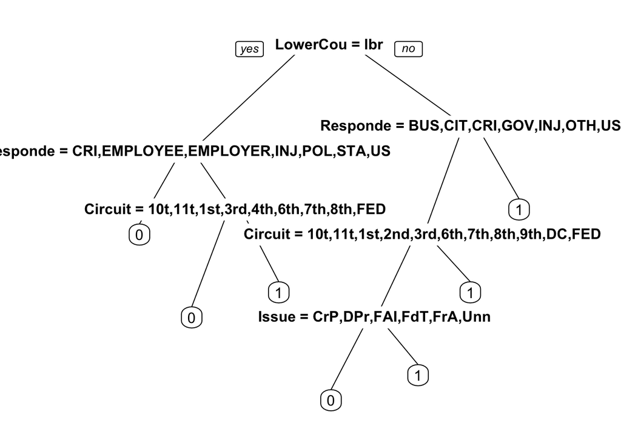

```r
library(rpart)
library(rpart.plot)
cartMod = rpart(Reverse ~ ., data=train, method="class", minbucket=25)
prp(cartMod)
```

대충 이런 결과가 나온다. 이 결과로 test set 을 검증해보자.

#### Test Set 검증

```r
cartPred = predict(cartMod, newdata=test, type="class")
cartTbl = table(test$Reverse, cartPred)
cartTbl
```

```
##    cartPred
##      0  1
##   0 44 33
##   1 28 65
```

```r
cartAccu = (cartTbl[1,1] + cartTbl[2,2])/sum(cartTbl)
cartAccu
```

```
## [1] 0.6411765
```

### Random Forest

#### Model 만들기

```r
library(randomForest)
rfMod = randomForest(Reverse ~ ., data=train, nodesize=25, ntree=200)
```

데이터 셋의 Rerverse 값이 factor 가 아니기 때문에 factor 로 변환 후 다시 실행한다.

```r
train$Reverse = as.factor(train$Reverse)
test$Reverse = as.factor(test$Reverse)
rfMod = randomForest(Reverse ~ ., data=train, nodesize=25, ntree=200)
```

#### Test Set 검증

```r
rfPred = predict(rfMod, newdata=test)
rfTbl = table(test$Reverse, rfPred)
rfTbl
```

```
##    rfPred
##      0  1
##   0 38 39
##   1 20 73
```

```r
rfAccu = (rfTbl[1,1] + rfTbl[2,2])/sum(rfTbl)
rfAccu
```

```
## [1] 0.6529412
```

Random Forest 모델의 정확도는 CART 모델과 비슷한 정도이다. 혹시나 minbucket size 때문에 그럴수도 있으므로 이 값을 조정하기 위해 cross validation 을 시도해보자.

### cp 값을 결정하기 위한 cross validation

#### K fold

```r
library(caret)
library(e1071)
trCtrl = trainControl(method="cv", number=10)
cpGrid = expand.grid(.cp=seq(0.001, 0.3, 0.001))
cvMod = train(Reverse ~ ., data=train, method="rpart", trControl=trCtrl, tuneGrid=cpGrid)
cvMod$bestTune
```

```
##        cp
## 222 0.222
```